Back to home page

# How my model is built

- What are the features used to build the model?
- How good is the model?
- How important are those features in my model?

### Load data

```python
%load_ext autoreload
%autoreload 2
```

```python
from sklearn.linear_model import Ridge
from sklearn.ensemble import RandomForestRegressor
from sklearn.metrics import r2_score, mean_absolute_error, mean_squared_log_error
import function as F
from airbnb_pipeline import *
import matplotlib.pyplot as plt
%config InlineBackend.figure_format = 'retina'
%matplotlib inline
plt.style.use('ggplot')
```

```python
listings = pd.read_csv('data/listings/listings.csv')
```

```python
listings.head(1)
```

|  | Unnamed: 0 | id | last_scraped | description | notes | transit | access | house_rules | host_since | host_response_time | ... | review_scores_rating | instant_bookable | cancellation_policy | calculated_host_listings_count | reviews_per_month | last30 | last60 | last90 | last120 | last180 |
| --- | --- | --- | --- | --- | --- | --- | --- | --- | --- | --- | --- | --- | --- | --- | --- | --- | --- | --- | --- | --- | --- |
| 0 | 5 | 8339 | 2018-05-09 | Pls email before booking. Interior featured i... | tax ID on file tax ID on file | NaN | Guests have access to everything listed and sh... | House Manual and House Rules will be provided ... | 2009-07-02 | within a few hours | ... | 97.0 | 0 | strict_14_with_grace_period | 2 | 0.25 | 0.0 | 0.0 | 0.0 | 0.0 | 0.0 |

1 rows × 40 columns

```python
listings.last_scraped = pd.to_datetime(listings.last_scraped)
```

### What are the features in my model?

Since I want to train a model for new host and predict his/her future revenue if he/she choose to use Airbnb service. Given this purpose, a lot of columns are not fit for first time users, so any review-related columns are excluded in my model, even though they contains very strong signals.

After multiple trials, I selected the following columns to train my model.

**Features:**

```
'price','room_type','guests_included','bedrooms','cleaning_fee',
'latitude','longitude','zipcode',
```

**Target:** `available_30`

- I train the model using all the data before 2017-11-01 and test the model using data after this day.
- Target is the total number of available days for next 30 days given that scraped days.
- Data is scraped from airbnb website at the beginning of every month from 2017 Jan to 2018 May.

```python
listings.shape[0]
```

```
41681
```

### Random Forest model

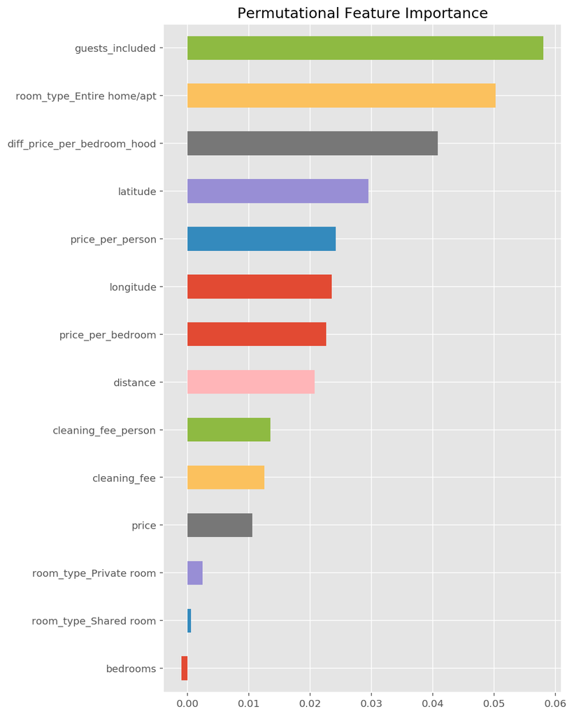

```python
X_train, X_test, y_train, y_test = F.my_train_test_split(listings, '2017-11-01')
p = Pipeline([
    ('pre_select', PreselectColumns()),  # Select columns to use in the training set
    ('FeatureEnginner', FeatureEnginner()), # Calculate price per person, perice per bedroom, distance from center, etc.
    ('PricePerBedroom', PricePerBedroom()), # calculate difference price per night vs average neighbourhood (zipcode)
    ('DropColumns', DropColumns()), # drop zipcode
    ('Getdummies', Getdummies()), # dummify categorical variable, drop not contributing columns
])
mod = p.fit(X_train,y_train)
X_train_post = mod.transform(X_train)
X_test_post = mod.transform(X_test)


rf = RandomForestRegressor(n_estimators=500)
rf.fit(X_train_post,y_train)


y_pred = rf.predict(X_test_post)

# Plot permutational feature importance using mean squared log error as metrics
neg_scorer = lambda y1, y2: mean_squared_log_error(y1, y2)*(-1)
feature_importance = F.permutation_importance(rf, X_test_post.values, y_test, scorer=neg_scorer)
series_feature_importance = pd.Series(feature_importance,index=X_train_post.columns.tolist())
feature_importance = series_feature_importance.copy()

F.plot_feature_importance(feature_importance)
```

Since the number of bedrooms feature appears both in the difference of price per bedroom compared to its neighborhood average level and price per bedroom, bedrooms itself becomes no longer important.

```python
print('Mean absolute error:',mean_absolute_error(y_test,np.clip(y_pred, 0, 30)))
print('Mean squared log error:',mean_squared_log_error(y_test,np.clip(y_pred, 0, 30)))
print('Mean R2 score:', r2_score(y_test,np.clip(y_pred, 0, 30)))
```

```
Mean absolute error: 5.63428383504
Mean squared log error: 0.381106740056
Mean R2 score: 0.263462185118
```

### Ridge model

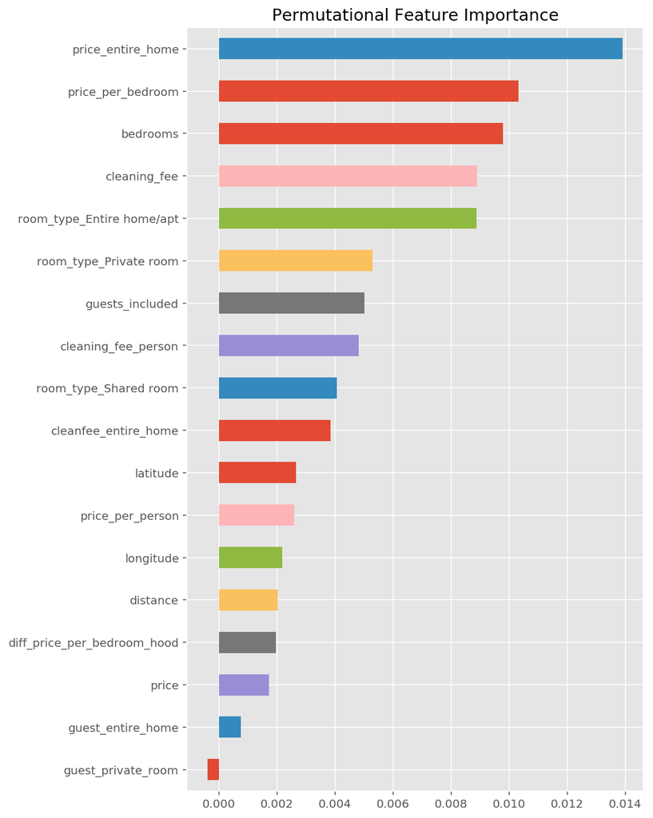

```python
p = Pipeline([
    ('pre_select', PreselectColumns()),  # Select columns to use in the training set
    ('FeatureEnginner', FeatureEnginner()), # Calculate price per person, perice per bedroom, distance from center, etc.
    ('PricePerBedroom', PricePerBedroom()), # calculate difference price per night vs average neighbourhood (zipcode)
    ('DropColumns', DropColumns()), # drop zipcode
    ('Getdummies', Getdummies()), # dummify categorical variable, drop not contributing columns
    ('Interaction', Interaction()), # Feature engineered some interaction between features
])
mod = p.fit(X_train,y_train)
X_train_post_lr = mod.transform(X_train)
X_test_post_lr = mod.transform(X_test)


lr = Ridge(alpha=0.0122,normalize=True)
lr.fit(X_train_post_lr,y_train)


y_pred = lr.predict(X_test_post_lr)


neg_scorer = lambda y1, y2: mean_squared_log_error(y1, np.clip(y2, 0, 30))*(-1)
feature_importance = F.permutation_importance(lr, X_test_post_lr.values, y_test, scorer=neg_scorer)
series_feature_importance = pd.Series(feature_importance,index=X_train_post_lr.columns.tolist())
feature_importance = series_feature_importance.copy()

F.plot_feature_importance(feature_importance)
```

Since Ridge is a linear model, I feature engineered some interaction between boolean features and numeric features.

- price_entire_home: price * room_type_entire_home
- cleanfee_entire_home: cleanning_fee * room_type_entire_home

```python
print('Mean absolute error:',mean_absolute_error(y_test,np.clip(y_pred, 0, 30)))
print('Mean squared log error:',mean_squared_log_error(y_test,np.clip(y_pred, 0, 30)))
print('Mean R2 score:', r2_score(y_test,np.clip(y_pred, 0, 30)))
```

```
Mean absolute error: 6.69362814495
Mean squared log error: 0.504611255357
Mean R2 score: 0.0708786089188
```

## Ensemble model

I made an ensemble model from Random Forest and Ridge. This weighted model performs better than any single of them.

```python
y_pred_lr = lr.predict(X_test_post_lr)
y_pred_rf = rf.predict(X_test_post)
y_pred = np.clip((y_pred_lr*0.2 + y_pred_rf*0.8),0,30)

print('Mean absolute error:', mean_absolute_error(y_test,y_pred))
print('Mean squared log error:', mean_squared_log_error(y_test,y_pred))
print('Mean R2 score:', r2_score(y_test,y_pred))
```

```
Mean absolute error: 5.52577194626
Mean squared log error: 0.365185613991
Mean R2 score: 0.312323521575
```

The mean absolute error is about 5.5 days, which means that the monthly revenue could also have an mean error of about 18% (5.5/30) disregarding other source of errors.

- average monthly revenue = price * (30 - available days)

### Residual plot

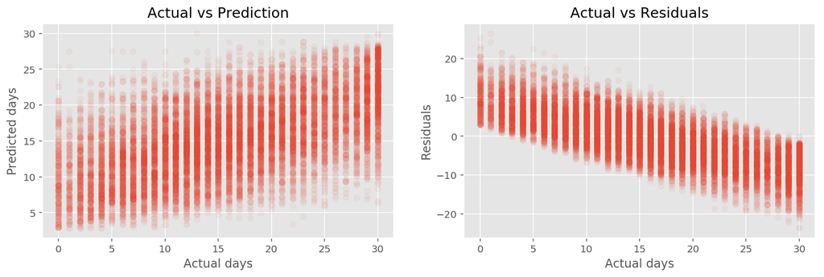

```python
fig = plt.figure(figsize=(14,4))
ax1 = fig.add_subplot(1,2,1)
ax2 = fig.add_subplot(1,2,2)
ax1.scatter(y_test, y_pred, alpha=0.05);
ax1.set_title('Actual vs Prediction')
ax1.set_xlabel('Actual days')
ax1.set_ylabel('Predicted days')

ax2.scatter(y_test, y_pred - y_test, alpha=0.05)
ax2.set_title('Actual vs Residuals')
ax2.set_xlabel('Actual days')
ax2.set_ylabel('Residuals');
```

The main difficulty is to predict the extreme value of 0 or 30.